# Same Bog Afterall:Border Discontinuity Study of Pennine Towns on the Greater Manchester Derbyshire Border

Sviatoslav

2026-07-29

“Over there: horror! Derbyshire! People get stuck in bogs, and they like it.”  
“On this side: Greater Manchester! Civilization! People get stuck in bogs, and they don’t like it.”-A certain Slovenian Philosopher

“I talk about doing for the rest of the country, what I have tried to do for Greater Manchester – Manchester-ism as we call it”Andy Burnham

## Motivation

For about 4 years i have been crossing the Manchester Derbyshire border in places like Saddleworth and Glossop without even knowing. Well apperently that entailed crossing the border between two completely different socieconomic stories in England, on one side is a great revival spurred on by the dynamic metropolitan area, on the other rural stagnation. A vision of Britain through time generously provide access to data compilations of national surveys from ONS and the like including the 10 year ones used for this study. Border Discontinuity design is an old if weird tradition in econometrics, where we attempt to mimic an experimental design by studying individuals or communities on different sides of an exogenously set boundary(in this case the administrative border) to eliminate selection bias and study the exact effect of policy of interest by proxy of being on different sides of the boundary. In our case we try and determine whether being on different sides of the GMA/derbyshire border meaningfully affected socioeconomic makeup of towns that are otherwise physically and socially extremely close together in survey years 1971,1981,1991,2001,2011 and 2021. The effect estimates will capture any effect unique to being administratively included in the manchester metropolitan area or indicate lack thereof, which may or may not provide extra evidence on whether manchesterism spills over to the pennines

**Methodology**

Instead of cutting through degrees of freedom like Nick Clegg through social spending we use 2 Generalised Additive Models to represent

theory 1 No divergence between GMP and derbyshire towns

$$\text{Proportion}_{i}
= \beta_{0}
+ \sum_{j=1}^{J} \gamma_{j} \, \mathbf{1}\{\text{Location}_{i} = j\}
+ s(\text{Year}_{i})
+ \varepsilon_{i},
\qquad \varepsilon_{i} \sim \mathcal{N}(0, \sigma^{2}).$$

Where s(Year) corresponds to base(k) 3 penalised smooth trend spline and y is town fixed effect

theory 2 Divergent unique non linear trends between the two towns

$$\text{Proportion}_{i}
= \beta_{0}
+ \sum_{j=1}^{J} \gamma_{j} \, \mathbf{1}\{\text{Location}_{i} = j\}
+ s_{0}(\text{Year}_{i}) \, \mathbf{1}\{\text{treatment}_{i}=0\}
+ s_{1}(\text{Year}_{i}) \, \mathbf{1}\{\text{treatment}_{i}=1\}
+ \varepsilon_{i}.$$

Where treatment 1 is the unique derbyshire trend and treatment 0 is the unique GMA trend

To measure divergence directly we also estimate a difference of smooths showing divergence between GMA and derby shire towns

d(Year)=s0(Year)−s1(Year).

For inference we adopt an evidentilist approach where Akaike scores and Relative Likelihoods correspond to odds of the model being the best predictive approximation and Schwarz scores and BF correspond to approximate posterior odds and evidence in favour of either of the theories given that the true or at least quasi true(plausible) model is included and all models are assumed equally likely before observing any data. the inverse of RL and BF conversely represents relative support for the other model. Although default AIC is an exact approximation for large enough n its biased towards more complex models in low n scenarios like this one. Therefore corrected AIC(AICc) is used instead as it includes an exact correction for small sample size which dissipates and becomes equivalent to default AIC as ratio of parameters to n shrinks.Therefore arguably the relative likelihoods derived from AICc are more trustworthy in our case than the ones derived from the Schwarz criterion.(For discussion on AICc vs BIC see appendix from Burnham and Anderson(2004).

**Data Gatherin**

The data used here was parsed from screenshots taken of Britain Vision through Time website accessible through this link https://www.visionofbritain.org.uk/unit/13505688/cube/NS_SEC_4WAY.

**Unemployment**

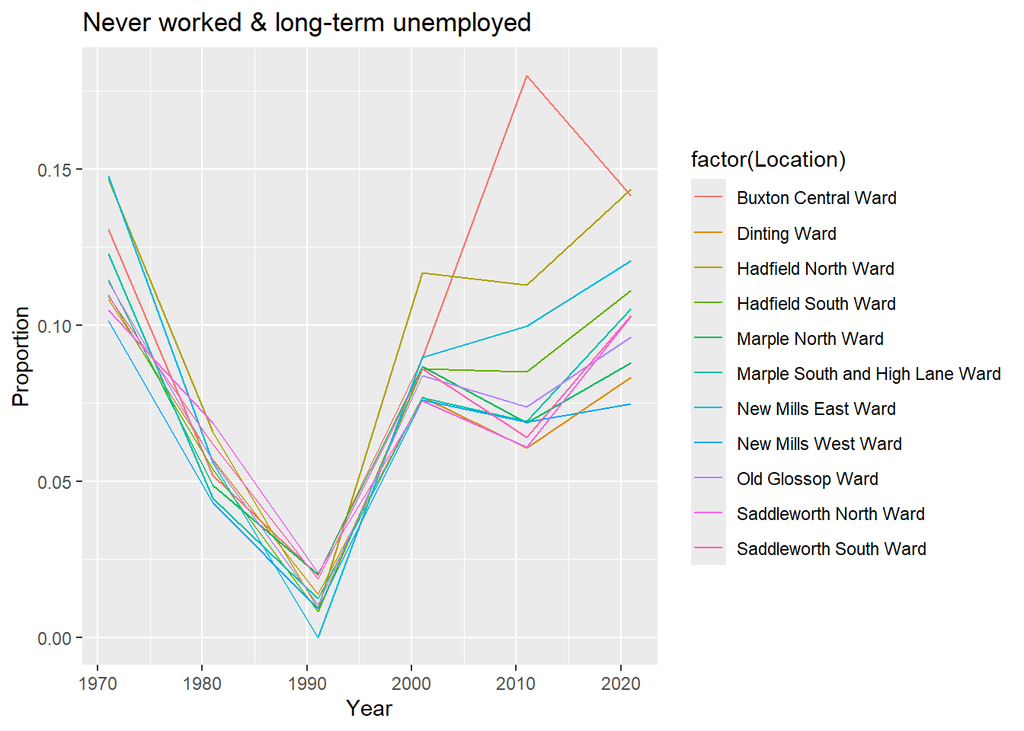

```r
unemployed <- na.omit(filter(gmppanel_prop,Classification=="Never worked & long-term unemployed"))
unemployed <- unemployed %>%
  filter(!(Location %in% c("Tameside District","High Peak District")),Year>=1971) %>%
  mutate(highpeak = factor(ifelse(Location %in%high_peak_areas, 1, 0)))
ggplot(data = unemployed,mapping = aes(x=Year,y=Proportion,colour = factor(Location)))+geom_line()+ggtitle(unique(unemployed$Classification))
```

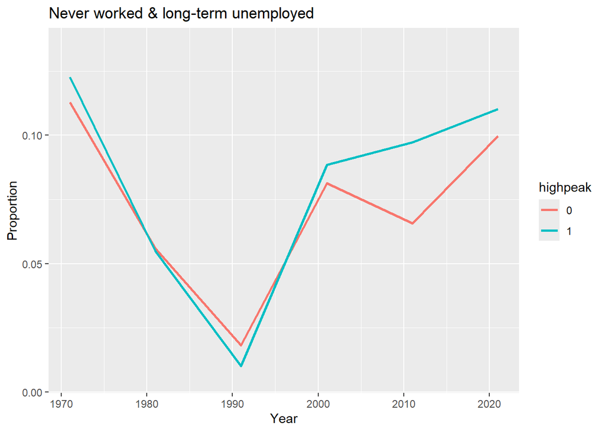

```r
ggplot(data = unemployed,mapping = aes(x=Year,y=Proportion,colour = highpeak))+stat_summary(
  fun.data = "mean_cl_boot", lwd=1,geom = "line"
)+ggtitle(unique(unemployed$Classification))
```

```r
spline1 <- gam(
  Proportion ~                        # Smooth trend for Reference Group (reduced k)
    s(Year, by = highpeak, k = 3) + # Difference spline (reduced k)
    factor(Location),          # Location fixed effects
  data = unemployed,
  method = "ML"
)
spliner <- gam(
  Proportion ~            # Parametric intercept difference
    s(Year, k = 3) +           # Smooth trend for Reference Group (reduced k)
    factor(Location),          # Location fixed effects
  data = unemployed,
  method = "ML" #Using ML so that information criteria are comparable acros smooths
)
model_comparisontable =tibble(SIC=c(BIC(spliner),BIC(spline1)),
                              Akaike=c(AICc(spliner),
                                       AICc(spline1))) #Using AICc to correct for small sample size
model_comparisontable = model_comparisontable %>% mutate(,ChangeSchwarz=SIC-min(SIC),ChangeAkaike=Akaike-min(Akaike),RL=exp(-0.5*(ChangeAkaike)),BF=(exp(-0.5*(ChangeSchwarz))))
cols_add(gt(model_comparisontable),theory=c("Single Pooled Trend","Two Different Trends"))
```

| SIC | Akaike | ChangeSchwarz | ChangeAkaike | RL | BF | theory |
| --- | --- | --- | --- | --- | --- | --- |
| -237.7779 | -260.5665 | 0.000000 | 0.000000 | 1.00000000 | 1.00000000 | Single Pooled Trend |
| -230.1119 | -254.5053 | 7.666027 | 6.061204 | 0.04828656 | 0.02164429 | Two Different Trends |

Assuming that the true plausible model is in our theory set the model with no divergence is 1/0.022=46 times more likely to be the true model in the set which is strong evidence in favour of no divergence on either side of the border. As a robustness check against a small sample size and given that the true model may not in the set we can use the AICc scores to calculate relative(to number of parameters) likelihoods as well. The no divergence model is 1/0.048=20.7 times more likely to minimise information loss and be the better approximation to the Data Generating Process than the one with separate trends. We therefore have strong or moderately strong evidence that the data supports the no divergence theory for unemployment trends regardless of whether we are looking at posterior trends or predictive power.

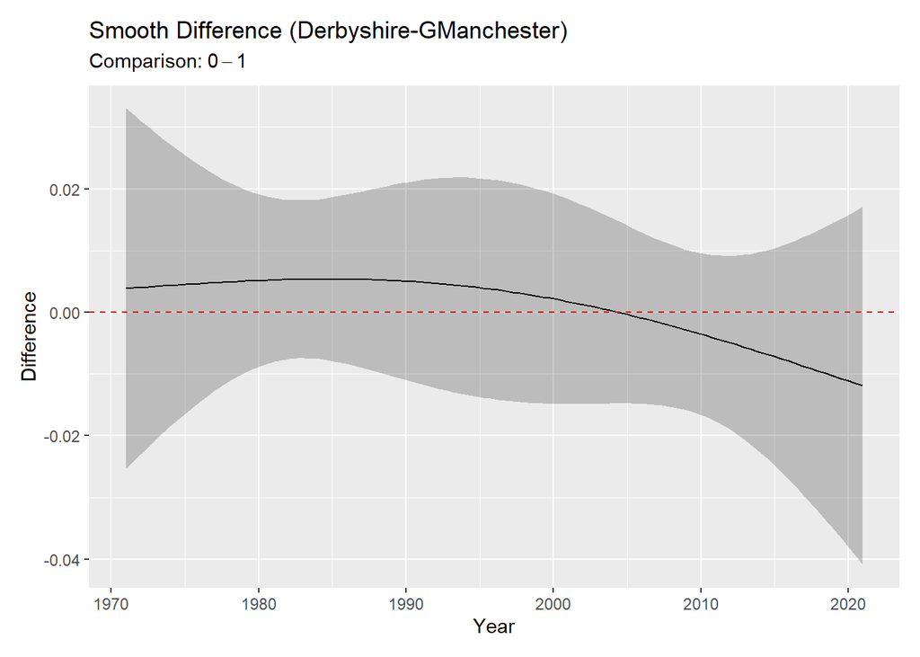

```r
diff_fit <- difference_smooths(spline1, "s(Year)")
# Plot the difference curve across time
draw(diff_fit) +
  geom_hline(yintercept = 0, linetype = "dashed", color = "red") +
  labs(title = "Smooth Difference (Derbyshire-GManchester)")
```

**Intermediate Jobs**

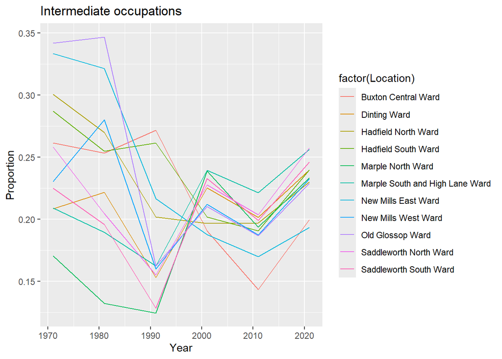

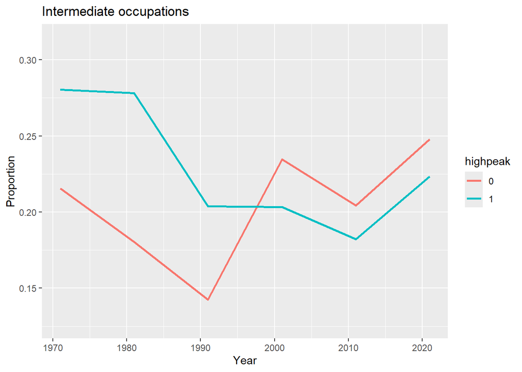

| SIC | Akaike | ChangeSchwarz | ChangeAkaike | RL | BF | theory |
| --- | --- | --- | --- | --- | --- | --- |
| -186.4157 | -209.2012 | 15.64126 | 17.23704 | 0.0001807274 | 0.0004013697 | Single Pooled Trend |
| -202.0569 | -226.4383 | 0.00000 | 0.00000 | 1.0000000000 | 1.0000000000 | Two Different Trends |

The Schwarz approximate posterior odds are that the divergent trends model is 2.5 thousand times more likely to be the true model in the set. Similarly the separate trends model is 5000 times more likely to be the better predictive approximation than the single pooled trend model. The data heavily supports the divergent trends model or at least heavily favours it as the better predictive model.

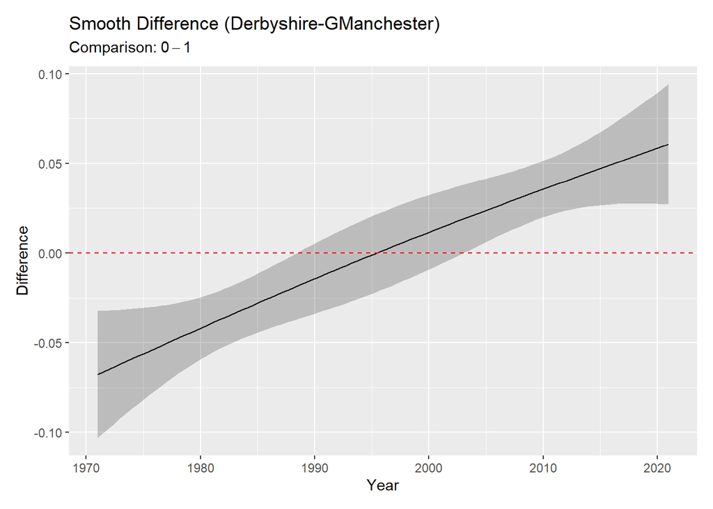

**Routine and Manual Jobs**

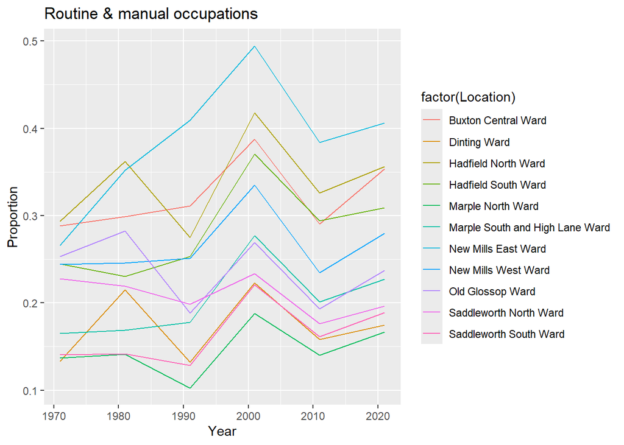

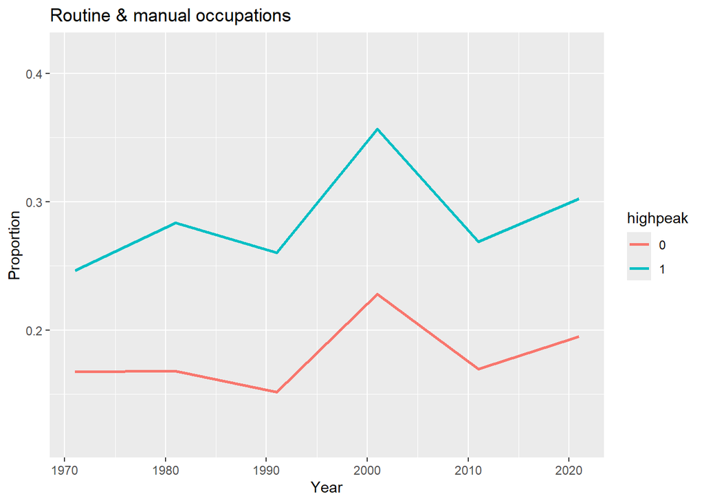

What saw much more continuity are routine and Manual Occupations. Although both groups are located in the Pennines the ones on the High Peak side started out with about 8 percent more people employed in these sorts of occupations be it construction work or more likely farm related work. What is arguably more interesting is that the gap stayed relatively balanced across survey waves with the groups moving more or less in tandem.This might point to the fact that towns in the high peak group are nonetheless much deeper in the Peak District and it’s Moors and thus have higher baseline structural propensity for this sector(something that fixed effects would account for).Still it’s clear that the trends are not perfectly parallel.

| SIC | Akaike | ChangeSchwarz | ChangeAkaike | RL | BF | theory |
| --- | --- | --- | --- | --- | --- | --- |
| -193.6899 | -216.4363 | 0.00000 | 0.000000 | 1.0000000 | 1.0000000 | Single Pooled Trend |
| -190.1222 | -213.7502 | 3.56768 | 2.686087 | 0.2610499 | 0.1679918 | Two Different Trends |

The evidence ratios reflect this higher uncertainty. The approximate Bayes factor in favour of the single trend model is 6 to 1 which constitutes weak evidence in favour of single trends as the divergence model still has some non negligible odds of being the true model. The information loss perspective is similiarly indecisive/weakly supportive of single trend model as the best approximation with it being 3.8 times more likely than the separate trends model to be the better approximation.At 26 percent probability of being the better model the 2 trends model still can’t be disregarded.The sample evidence therefore offers relatively weak support for the single trend model regardless of whether one looks at posterior odds or choosing the best approximation.

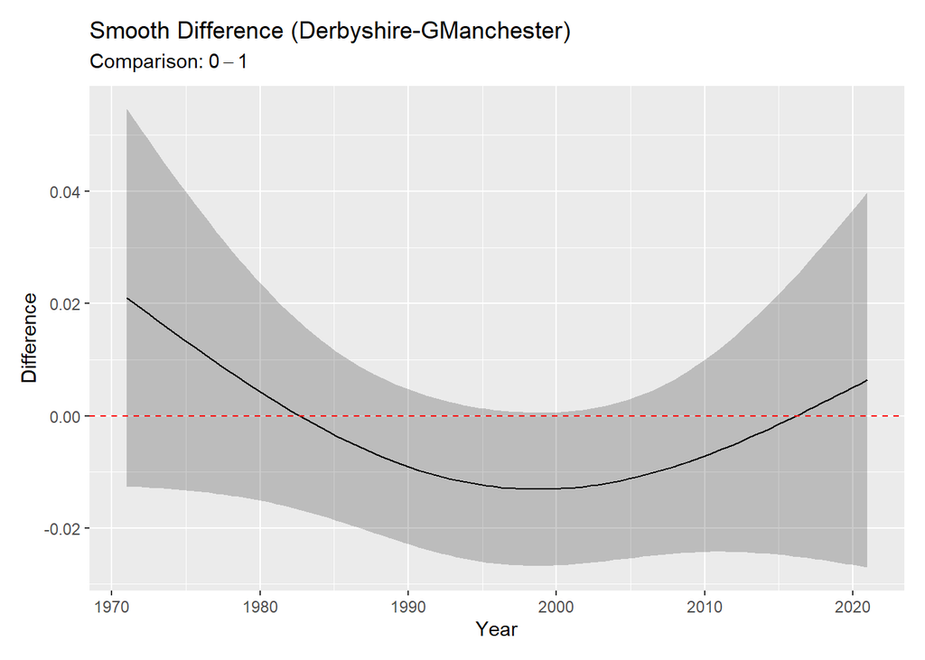

The smooth difference plots show very high uncertainty at the start and the end of the survey Overall although both approximate posterior odds and the relative likelihood evidential approaches favour the model under which both groups have near parallel trends in those working in routine and Manual Occupations they arguably do not rule out the divergence model with enough certainty that we could argue that it’s the theory conclusively supported by the data.In spite of clear visual evidence we only have weak in sample support for no significant divergence theory.Although only weakly supported by the data we have that the groups maintained their baseline differences in manual work patterns overtime.

**Higher Administrative and Managerial Jobs**

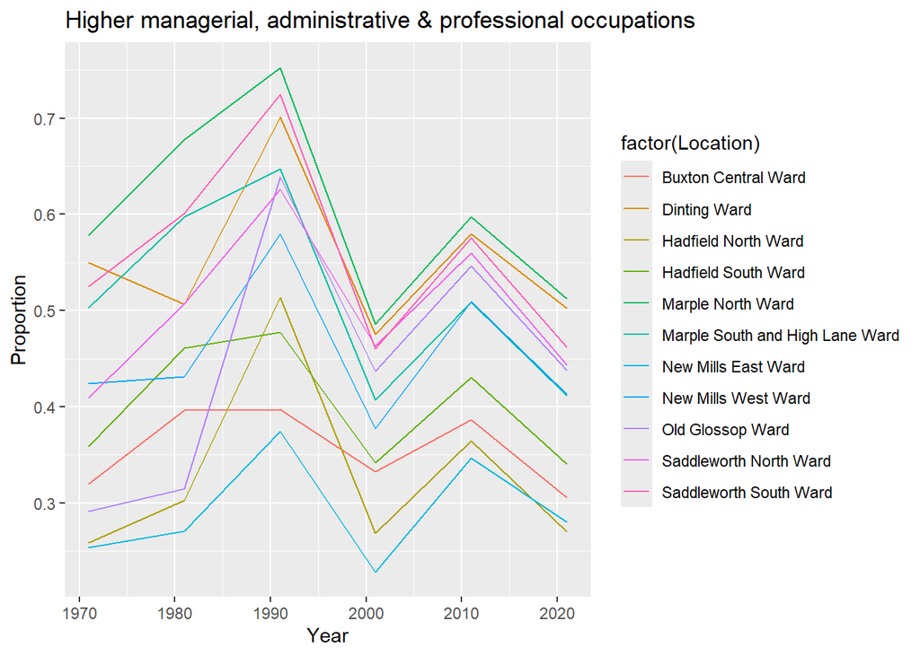

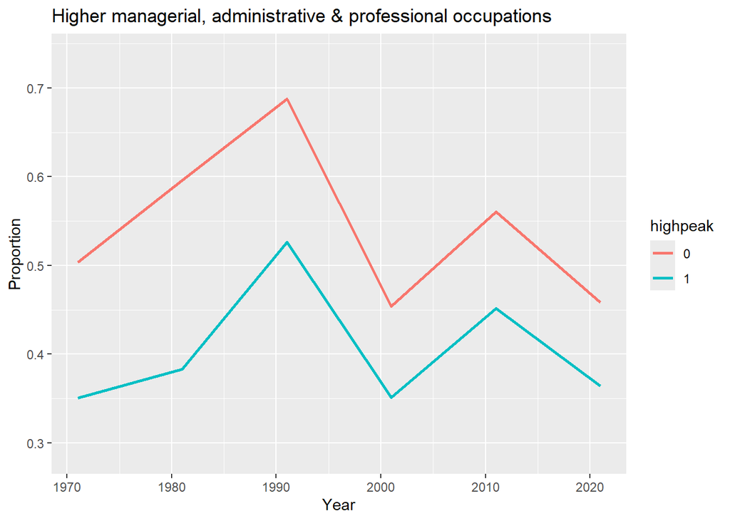

The story is flipped for high managerial/admin roles. Even in 1971 the GM towns already dominated their high peak counterparts by about 15 percent. Even if the plot suggests that the gap narrowed slightly.

| SIC | Akaike | ChangeSchwarz | ChangeAkaike | RL | BF | theory |
| --- | --- | --- | --- | --- | --- | --- |
| -106.3326 | -129.1186 | 0.000000 | 0.000000 | 1.00000 | 1.00000000 | Single Pooled Trend |
| -101.5852 | -125.9641 | 4.747476 | 3.154426 | 0.20655 | 0.09313194 | Two Different Trends |

But did it really? The bayes factor in favour of the no divergence model by 11 to 1 which is moderately strong evidence. However if we drop the m closed assumption and use Relative Likelihoods derived from the more small n robust AICc the story is far less rosy with the 4.9 to 1 evidence for pooled trend model to be the best approximating model. Being.skeptical we follow the likelihoods efficient at small m and therefore have modest to anecdotal evidence in favour of the no divergence model as the best approximating model.We still can’t fully rule out if the divergent model were a better fit.

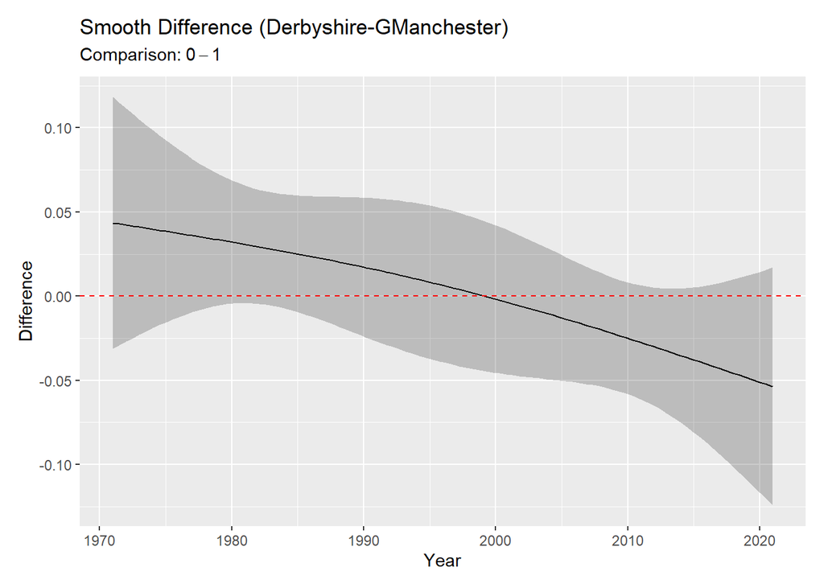

Like with manual jobs it’s highly likely that the gap between the tol groups stayed more or less constant overtime as seen by confidence bands hugging and crossing zero. We cannot however rule out relatively small divergence between groups overtime that might still mean that the divergence theory is not dead in the water.

Appendix

“The model selection literature often errs by considering that AIC and BIC selection are directly comparable, as if they had the same objective target model. Their target models are different (Reschenhofer 1996). The target model of AIC is one that is specific for the sample size at hand: It is the fitted model that minimizes expected estimated K-L information loss when fitted model gr is used to approximate full reality, f. This target model changes with sample size. Moreover, in this overall philosophy, even the set of models is expected to be changed if there are large changes in n. Theclassica lderivation of BIC assumed that there was a true model, independent of n, that generated the data; it was a model in the model set, and this true model was the target model for selection by BIC. However, selection of this true model with probability 1 only occurs in the limit as n gets very large, and in taking that limit, the model set is kept fixed. The original derivation of BIC has been relaxed, wherein we realize that such convergence only justifies an inference of a quasi-true model (the most parsimonious model closest in K-L information to truth).

From

**Burnham, K.P. and Anderson, D.R.** **(2004) Multimodel Inference: Understanding**

**AIC and BIC in Model Selection.** **Sociological Methods & Research, 33, 261-304**.